# spGARCH: An R-Package for Spatial and Spatiotemporal ARCH and GARCH models

In this paper, a general overview on spatial and spatiotemporal ARCH models is provided. In particular, we distinguish between three different spatial ARCH-type models. In addition to the original definition of (Otto et al. 2016), we introduce an logarithmic spatial ARCH model in this paper. For this new model, maximum-likelihood estimators for the parameters are proposed. In addition, we consider a new complex-valued definition of the spatial ARCH process. Moreover, spatial GARCH models are briefly discussed. From a practical point of view, the use of the R-package [*spGARCH*](https://CRAN.R-project.org/package=spGARCH) is demonstrated. To be precise, we show how the proposed spatial ARCH models can be simulated and summarize the variety of spatial models, which can be estimated by the estimation functions provided in the package. Eventually, we apply all procedures to a real-data example.

Philipp Otto (Leibniz University Hannover)  
2019-12-28

## 1 Introduction

Whereas autoregressive conditional heteroscedasticity (ARCH) models are applied widely in time series analysis, especially in financial econometrics, spatial conditional heteroscedasticity has not been seen as critical issue in spatial econometrics up to now. Although it is well-known that classical least squares estimators are biased for spatially correlated data as well as for spatial data with an inhomogeneous variance across space, there are just a few papers proposing statistical models accounting for spatial conditional heteroscedasticity in terms of the ARCH and GARCH models of (Engle 1982) and (Bollerslev 1986). The first extensions to spatial models attempted were time series models incorporating spatial effects in temporal lags (see Borovkova and Lopuhaa (2012) and Caporin and Paruolo (2006), for instance). Instantaneous spatial autoregressive dependence in the conditional second moments, i.e., the conditional variance in each spatial location is influenced by the variance nearby, has been introduced by (Otto et al. 2016). Further details and derivations can also be found in (Otto et al. 2018, 2019). Their models allow for these instantaneous effects but require certain regularity conditions. In this paper, we propose an alternative specification of spatial autoregressive conditional heteroscedasticity based on an exponential definition of the conditional variance. This new model can be seen as the spatial equivalent of the log-GARCH model by (Geweke 1986; Pantula 1986; Milhøj 1987). Other recent papers propose a mixture of these two approaches (see Sato and Matsuda (2017, 2018a)). Moreover, all these models can be used in spatiotemporal settings (see Otto et al. (2018; Sato and Matsuda 2018b)).

In addition to the novel spatial logarithmic ARCH model, this paper demonstrates the use of the R-package [*spGARCH*](https://CRAN.R-project.org/package=spGARCH). From this practical point of view, the simulation of several spatial ARCH-type models as well as the estimation of a variety of spatial models with conditional heteroscedasticity are shown. There are several packages implementing geostatistical models, kriging approaches, and other spatial models (cf. Cressie (1993; Cressie and Wikle 2011)). One of the most powerful packages used to deal with models of spatial dependence is [*spdep*](https://CRAN.R-project.org/package=spdep), written by (Bivand and Piras 2015). It implements most spatial models in a user-friendly way, such as spatial autoregressive models, spatial lag models, and so forth (see, also, Elhorst (2010) for an overview). These models are typically called spatial econometrics models, although they are not tied to applications in economics. In contrast, the package [*gstat*](https://CRAN.R-project.org/package=gstat) provides functions for geostatistical models, variogram estimation, and various kriging approaches (see Pebesma (2004) for details). For dealing with big geospatial data, the [*Stem*](https://CRAN.R-project.org/package=Stem) package uses an expectation-maximization (EM) algorithm for fitting hierarchical spatiotemporal models (see Cameletti (2015) for details). For a distributed computing environment, the MATLAB software D-STEM from (Finazzi and Fasso 2014) also provides powerful tools for dealing with heterogeneous spatial supports, large multivariate data sets, and heterogeneous spatial sampling networks. Additionally, these fitted models are suitable for spatial imputation. Contrary to these EM approaches, Bayesian methods for modeling spatial data are implemented in the R-*INLA* package (see Rue et al. (2009) for technical details of the integrated nested Laplace approximations and Martins et al. (2013) for recently implemented features). Along with this package, the R-*INLA* project provides several functions for diverse spatial models incorporating integrated nested Laplace approximations.

In contrast to the above mentioned software for spatial models, the prevalent R-package for time series GARCH-type models is [*rugarch*](https://CRAN.R-project.org/package=rugarch) from (Ghalanos 2018). Since [*spGARCH*](https://CRAN.R-project.org/package=spGARCH) has been developed mainly to deal with spatial data, we aim to provide a package which is user-friendly for researchers and data scientists working in applied spatial science. Thus, the package is coordinated with the objects and ideas of R packages for spatial data rather than packages for dealing with time series.

We structure the paper as follows. In the next Section 2, we discuss all covered spatial and spatiotemporal ARCH-type models. In addition, we introduce a novel logarithmic spatial ARCH model, which has weaker regularity conditions than the other spatial ARCH models. In the subsequent section, parameter estimation based on the maximum-likelihood principle is discussed for both the previously proposed spatial ARCH models as well as the new logarithmic spatial ARCH model. Furthermore, spatial GARCH models are briefly discussed. However, the focus of this paper should be on ARCH-type models. After these theoretical sections, we demonstrate the use of the R-package [*spGARCH*](https://CRAN.R-project.org/package=spGARCH) in Section 5. Further, we fit a spatial autoregressive model with exogenous regressors and spatial ARCH residuals for a real-world data set. In particular, we analyze prostate cancer incidence rates in southeastern U.S. states. Section 7 concludes the paper.

## 2 Spatial ARCH-type models

Let $\left\{Y(\boldsymbol{s}) \in \mathbb{R}: \boldsymbol{s} \in D \right\}$ be a univariate stochastic process having a spatial autoregressive structure in the conditional variance. The process is defined in a multidimensional space $D$, which is typically a subset of the $q$-dimensional real numbers $\mathbb{R}^q$, as space is usually finite. For dealing with spatial lattice data, $D$ is subset of the $q$-dimensional integers $\mathbb{Z}^q$. For both cases, it is important that the subset contains a $q$-dimensional rectangle of positive volume (cf. Cressie and Wikle (2011)). Moreover, this definition is suitable for modeling spatiotemporal data, as one might assume that $D$ is the product set $\mathbb{R}^{k} \times \mathbb{Z}^{l}$ with $k + l = d$.

To define spatial models, in particular areal spatial models such as the simultaneous autoregressive (SAR) models, it is convenient to consider a vector of observations $\boldsymbol{Y} = (Y(\boldsymbol{s}_1), \ldots, Y(\boldsymbol{s}_n))^\prime$ at all locations $\boldsymbol{s}_1, \ldots, \boldsymbol{s}_n$. For spatial ARCH models, we specify this vector as
$$\label{eq:spARCHy}
\boldsymbol{Y} = \mathrm{diag}(\boldsymbol{h})^{1/2}\boldsymbol{\varepsilon} \, , \tag{1}$$
an analogue to the well-known time series ARCH models (cf. Engle (1982; Bollerslev 1986)). However, note that the vector $\boldsymbol{h}$ does not necessarily coincide with the conditional variance
$$Var(Y(\boldsymbol{s}_i) | Y(\boldsymbol{s}_1), \ldots, Y(\boldsymbol{s}_{i-1})) \, ,$$
as the variance in any location $\boldsymbol{s}_j$ also depends on $Y(\boldsymbol{s}_i)$ for $j \neq i$ (see Otto et al. (2018) for details). We now distinguish between several spatial ARCH-type models via the definition of $\boldsymbol{h}$.

### 2.1 Spatial ARCH model

First, we define this vector $\boldsymbol{h}$ in such a way as to be analogous to the definition in (Otto et al. 2018). For this model, the vector $\boldsymbol{h}_O$ is given by
$$\label{eq:h_spARCH}
\boldsymbol{h}_O = \alpha\boldsymbol{1} + \rho\mathbf{W} \mathrm{diag}(\boldsymbol{Y}) \boldsymbol{Y} \, , \tag{2}$$
where $\mathrm{diag}(\boldsymbol{a})$ is a diagonal matrix with the entries of $\boldsymbol{a}$ on the diagonal. In order to be consistent with the implementation in the R-package [*spGARCH*](https://CRAN.R-project.org/package=spGARCH), we focus on the special case with two parameters $\alpha$ and $\rho$, whereas (Otto et al. 2018) proposed a more general model with a vector $\boldsymbol{\alpha} = (\alpha_1, \ldots, \alpha_n)'$ and the first-order spatial lag $\mathbf{W}\mathrm{diag}(\boldsymbol{Y}) \boldsymbol{Y}$.

For this definition, there is a one-to-one relation between $\boldsymbol{Y}$ and $\boldsymbol{\varepsilon}$ via the squared observations $\boldsymbol{Y}^{(2)} = (Y(\boldsymbol{s}_1)^2, \ldots, Y(\boldsymbol{s}_n)^2)^\prime$ and squared errors $\boldsymbol{\varepsilon}^{(2)} = (\varepsilon(\boldsymbol{s}_1)^2, \ldots, \varepsilon(\boldsymbol{s}_n)^2)^\prime$ with
$$\label{eq:Y2}
\boldsymbol{Y}^{(2)} = \alpha \, \left(\mathbf{I} - \mathbf{A} \right)^{-1} \boldsymbol{\varepsilon}^{(2)}\, , \tag{3}$$
where $\mathbf{W}$ is a predefined spatial weighting matrix and
$$\label{eq:A}
\mathbf{A} = \rho \, \mathrm{diag}\left(\varepsilon(\boldsymbol{s}_1)^2, \ldots, \varepsilon(\boldsymbol{s}_n)^2\right) \mathbf{W} \, . \tag{4}$$
Thus,
$$\boldsymbol{h}_O = \alpha\boldsymbol{1} + \rho \alpha \mathbf{W} \left(\mathbf{I} - \mathbf{A} \right)^{-1} \boldsymbol{\varepsilon}^{(2)} \, .$$

It is important to assume that the spatial weighting matrix is a non-stochastic, positive matrix with zeros on the main diagonal to ensure that a location is not influenced by itself (cf. Elhorst (2010; Cressie and Wikle 2011)). The vector of random errors is denoted by $\boldsymbol{\varepsilon}$. Due to the complex dependence implied by the weighting matrix $\mathbf{W}$, $\boldsymbol{h}_O$ is not necessarily positive; thus, $\mathrm{diag}(\boldsymbol{h})^{1/2}$ does not necessarily have a solution in the real numbers such that the process in (1) is well-defined. This is only the case if the condition of the following lemma is fulfilled.

**Lemma 1** (Otto et al. (2018)). Suppose that $\alpha \geq 0$, $\rho \geq 0$ and that $\det(\mathbf{I} - \mathbf{A}^2) \neq 0$. If all elements of the matrix
$$\label{eq:inverse_I-A}
(\mathbf{I} - \mathbf{A}^2)^{-1}%%% \tag{5}$$
are nonnegative, then all components of $\boldsymbol{Y}^{(2)}$ are nonnegative, i.e., $Y(\boldsymbol{s}_i)^2 \ge 0$ for $i=1,\ldots,n$. Moreover, $h_O(\boldsymbol{s}_i) \ge 0$ for $i=1,\ldots,n$.

It is important to note that $\mathbf{A}$ depends on both the weighting matrix and the realizations of the errors. In order to ensure that this condition is fulfilled, (Otto et al. 2018) propose to truncate the support of the error distribution on the interval $(-a, a)$ with
$$a = \left\{
\begin{array}{cc}
\infty & \exists k > 0 : \rho\mathbf{W}^k = \mathbf{0} \\ % \rho = 0 \; \vee \;
{1}/{\sqrt[4]{ \rho^2||\mathbf{W}^2 ||_1}} & \rho^2 || \mathbf{W}^2 ||_1 > 0
\end{array} \right. \, ,$$
where $|| \cdot ||_1$ denotes the matrix norm based on the Manhattan norm.

There are two cases in which the support of the errors does not need to be constrained. If $\rho = 0$, the process coincides with a spatial white noise process such that $a$ equals $\infty$. Moreover, all entries of $\boldsymbol{h}$ are non-negative if $\mathbf{W}$ is similar to a strictly triangular matrix. Then, $\mathbf{W}$ is nilpotent. This case covers the classical time-series ARCH($p$) models introduced by (Engle 1982) as well as the so-called oriented spARCH processes. For these processes, the spatial dependence has a certain direction, e.g., observations are only influenced by observations in a southward direction or by observations which are closer to an arbitrarily chosen center. The setting also covers recent time-series GARCH models incorporating spatial information (e.g., (Caporin and Paruolo 2006; Borovkova and Lopuhaa; 2012)).

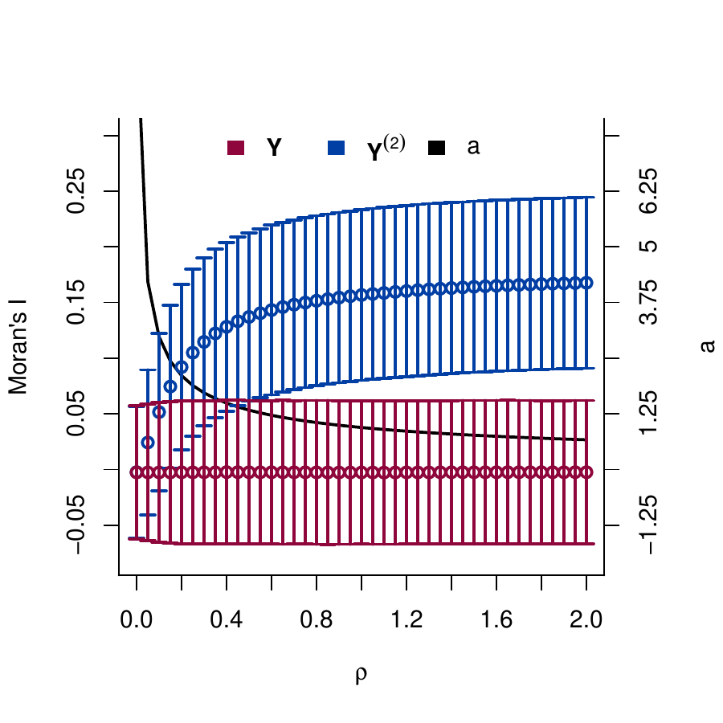

Figure 1: Moran’s $I$ of the observations $\boldsymbol{Y}$ and the squared observations $\boldsymbol{Y}^{(2)}$, including the asymptotic 95% confidence intervals of $I$ for $\rho \in \{0,0.05, \ldots, 2\}$. The resulting bound $a$ is plotted as a bold, black line.

### 2.2 Spatial Log-ARCH model

Next, we consider an logarithmic spatial ARCH process (log-spARCH). In this setting, we define the natural logarithm of $\boldsymbol{h}_E = (h_{E}(\boldsymbol{s}_1), \ldots, h_{E}(\boldsymbol{s}_n))'$ as
$$\label{eq:EspARCHh}
\ln \boldsymbol{h}_E = \alpha\boldsymbol{1} + \rho\mathbf{W} g_b(\boldsymbol{\varepsilon}) \, , \tag{6}$$
with a function $g_b: \mathbb{R}^n \rightarrow \mathbb{R}^n$. Like (Nelson 1991), we assume that
$$g_b(\boldsymbol{\varepsilon}) = (\ln |\varepsilon(\boldsymbol{s}_1)|^b, \ldots, \ln |\varepsilon(\boldsymbol{s}_n)|^b)'$$
for positive values of $b$. For this definition, there is a one-to-one relation between $\boldsymbol{Y}$ and $\boldsymbol{\varepsilon}$, as we show in the following theorem.

**Theorem 1**. *Suppose that $\alpha > 0$, $\rho \geq 0$, and $w_{ij} \geq 0$ for all $i,j = 1, \ldots, n$ and $g_b(\boldsymbol{\varepsilon}) = (\ln |\varepsilon(\boldsymbol{s}_1)|^b, \ldots, \ln |\varepsilon(\boldsymbol{s}_n)|^b)'$. Then there exists one and only one $Y(\boldsymbol{s}_1), \ldots, Y(\boldsymbol{s}_n)$ that corresponds to each $\varepsilon(\boldsymbol{s}_1), \ldots, \varepsilon(\boldsymbol{s}_n)$ for $b > 0$.*

At location $\boldsymbol{s}_i$, the value of $h_{E}(\boldsymbol{s}_i)$ is then given by
$$\ln h_{E}(\boldsymbol{s}_i) = \alpha + \sum_{v=1}^{n} \rho b w_{iv} \ln |\varepsilon(\boldsymbol{s}_v)| \; \text{for} \; i = 1, \ldots, n\, .$$
For this definition of $g_b$, one could rewrite $\ln \boldsymbol{h}$ as
$$\label{eq:h_EspARCH}
\ln \boldsymbol{h}_E = \mathbf{S} \left(\alpha\boldsymbol{1} + \rho b \mathbf{W} \ln|\boldsymbol{Y}|\right) \tag{7}$$
with
$$\mathbf{S} = (s_{ij})_{i,j = 1, \ldots, n} = \left(\mathbf{I} + \frac{1}{2} \rho b \mathbf{W}\right)^{-1} \, .$$
In contrast to the spARCH process described in Section 2.1, Corollary 1 shows that the entries of $\boldsymbol{h}_E$ are positive for all $\rho \geq 0$ and $\alpha > 0$. Hence, the process is well-defined and there are no further restrictions needed, as in the case for the spARCH model.

**Corollary 1**. *Assume that the assumptions of Theorem 1 are fulfilled, then $\boldsymbol{h}_{E}(\boldsymbol{s}_i) \geq 0$ for all $i = 1, \ldots, n$.*

For all proofs, we refer to the Appendix.

### 2.3 Complex Spatial ARCH model

Now, we propose a complex-valued spARCH process. In order to obtain a solution of $\mathrm{diag}(\boldsymbol{h})^{1/2}$ in the $n$-dimensional space of real numbers for the model defined in (2), all elements of the matrix $(\mathbf{I} - \mathbf{A}^2)^{-1}$ must be nonnegative (see Otto et al. (2018)). For the complex spARCH process, we relax the assumption that there should be a solution to $\mathrm{diag}(\boldsymbol{h})^{1/2}$ in the real numbers and also consider complex solutions. Thus, the definition of $\boldsymbol{h}$ coincides with $\boldsymbol{h}_O$ of the original model, i.e.,
$$\label{eq:complexspARCH}
h_{C}(\boldsymbol{s}_i) = \alpha + \sum_{v=1}^{n} \rho w_{iv} Y(\boldsymbol{s}_v)^2 \, . \tag{8}$$

### 2.4 Spatiotemporal ARCH model

Table 1: Overview of all types of spARCH models implemented in the [*spGARCH*](https://CRAN.R-project.org/package=spGARCH) package.

[output not shown]

### 2.5 Spatial ARCH Disturbances

Since all conditional and unconditional odd moments of spatial ARCH processes are equal to zero, these ARCH-type models can easily be added to any kind of (spatial) regression model without influencing the mean equation as well as the spatial dependence in the first conditional and unconditional moments. This makes the spatial ARCH models flexible tools for dealing with conditional spatial heteroscedasticity in the residuals of spatial models. For instance, one can consider spatial autoregressive models for $\boldsymbol{Y}$, i.e.,
$$\begin{aligned}
\label{eq:SARspARCH1}
\boldsymbol{Y} = \lambda \mathbf{B} \boldsymbol{Y} + \mathbf{X} \boldsymbol{\beta} + \boldsymbol{u}
\end{aligned} \tag{9}$$
with $\boldsymbol{u}$ following either a spatial ARCH model with the original definition $\boldsymbol{h}_O$ or the logarithmic model with $\boldsymbol{h}_E$. Thus,
$$\begin{aligned}
\label{eq:SARspARCH2}
\boldsymbol{u} = \mathrm{diag}(\boldsymbol{h})^{1/2}\boldsymbol{\varepsilon} \, .
\end{aligned} \tag{10}$$
Further, we call this model the SARspARCH model. For $\lambda = 0$, the model collapses to a simple linear regression model; if, additionally, $\boldsymbol{\beta} = \boldsymbol{0}$, the model coincides with the previously discussed ARCH models. Thus, these coefficients can be used for testing against nested models.

In contrast to other models for heteroscedastic errors, such as the SARAR or SARMA models, which assume spatial autoregressive or spatial moving average error terms (cf. (Haining 1978; Fingleton 2008; Kelejian and Prucha; 2010)), the SARspARCH model does not affect the spatial autocorrelation of the process, just the spatial heteroscedasticity, because all conditional and unconditional odd moments are equal to zero. Thus, $\lambda \mathbf{B}$ can be interpreted directly as the spatial dependence of the process, while $\rho \mathbf{W}$ describes the spatial dependence in the second conditional moments. Moreover, these two parts can be interpreted separately, as we will demonstrate in the last section via an empirical example.

## 3 Generalized Spatial ARCH Models

Additionally, one may include spatially lagged observations of $\boldsymbol{h}$ to construct spatial GARCH-type models. For instance, a spatial GARCH model is given by
$$\begin{aligned}
\label{eq:h_spGARCH}
\boldsymbol{h}_G & = & \alpha\boldsymbol{1} + \rho\mathbf{W} \mathrm{diag}(\boldsymbol{Y}) \boldsymbol{Y} + \lambda \breve{\mathbf{W}} \boldsymbol{h}_G \\
& = & (\mathbf{I} - \lambda \breve{\mathbf{W}})^{-1} \left(\alpha\boldsymbol{1} + \rho\mathbf{W} \mathrm{diag}(\boldsymbol{Y}) \boldsymbol{Y} \right) \, ,
\end{aligned} \tag{11}$$
where $\breve{\mathbf{W}}$ is a second spatial weighting matrix and $\lambda$ is the corresponding spatial GARCH parameter. Obviously, the spatial GARCH-type models requires that $(\mathbf{I} - \lambda \breve{\mathbf{W}})$ is non-singular. In a similar manner, $\boldsymbol{h}_{LG}$ can be specified as
$$\label{eq:h_EspGARCH}
\ln \boldsymbol{h}_{LG} = \alpha\boldsymbol{1} + \rho\mathbf{W} g_b(\boldsymbol{\varepsilon}) + \lambda \breve{\mathbf{W}} \boldsymbol{h}_{LG} \, , \tag{12}$$
to define a spatial log-GARCH model. For theoretical details of spatial GARCH-type models, we refer to (Otto and Schmid 2019) introducing a unified spatial GARCH model covering various spatial ARCH and GARCH models. Moreover, (Otto and Schmid 2019) introduce an exponential spatial GARCH model allowing for asymmetry via an alternative definition of $g$ in (6). To be precise, $g$ is given by
$$g(\boldsymbol{\varepsilon}) = (\Theta \varepsilon_1 + \zeta (|\varepsilon_1| - E(|\varepsilon_1|) ), \ldots, \Theta \varepsilon_n + \zeta (|\varepsilon_n| - E(|\varepsilon_n|) )'$$
for the exponential spatial GARCH model.

## 4 Parameter Estimation

The parameters of a spatial ARCH process can be estimated by the maximum-likelihood approach. To obtain the joint density for $\boldsymbol{Y} = k(\boldsymbol{\varepsilon})$, the Jacobian matrix of $k^{-1}$ at the observed values $\boldsymbol{y}$ must be computed (e.g., Bickel and Doksum (2015)). If $f_{\boldsymbol{\varepsilon}}$ is the distribution of the error process, then the joint density $f_{\boldsymbol{Y}}$ of $\boldsymbol{Y}$ is given by
$$\begin{aligned}
\label{eq:transformation}
f_{\boldsymbol{Y}}(\boldsymbol{y}) & = & f_{(Y(\boldsymbol{s}_1), \ldots, Y(\boldsymbol{s}_n))}(y_1, \ldots, y_n) \nonumber \\
& = & f_{\boldsymbol{\varepsilon}}\left(\frac{y_1}{\sqrt{h}_1}, \ldots, \frac{y_n}{\sqrt{h}_n}\right) | \det\left( \left( \frac{\partial y_j/\sqrt{h_j}}{\partial y_i} \right)_{i,j=1,\ldots,n}\right) | \, .
\end{aligned} \tag{13}$$
If the residuals are additionally independent and identically distributed, the parameter estimates can be obtained from the maximization of the log-likelihood as follows
$$\begin{aligned}
(\hat{\alpha}, \hat{\rho}) = \underset{\alpha > 0, \rho \geq 0}{\arg\max} \; \ln | \det\left( \left( \frac{\partial y_j/\sqrt{h_j}}{\partial y_i} \right)_{i,j=1,\ldots,n}\right) | + \sum_{i = 1}^{n} \ln f_{\varepsilon}(y_i) \, .
\end{aligned}$$

The Jacobian matrix, of course, depends on the definition of $\boldsymbol{h}$. For the spARCH process, this Jacobian matrix can be specified as
$$\frac{\partial y_j/\sqrt{h_j}}{\partial y_i} = \left\{
\begin{array}{ccc}
1\, /\, \sqrt{h}_j & for & i=j \\
- \frac{y_i y_j}{h_j^{3/2}} \rho w_{ji} & for & i \neq j
\end{array} \right. \, .$$
In contrast, the Jacobian matrix for the log-spARCH process is slightly different, namely
$$\frac{\partial y_j/\sqrt{h_j}}{\partial y_i} = \left\{
\begin{array}{ccc}
1\, /\, \sqrt{h_j} & for & i = j \\
- \frac{b y_j}{2 y_i h_j^{3/2}} \rho s_{ji} w_{ji} & for & i \neq j
\end{array} \right. \,$$
with
$$h_j = \mathrm{exp}\left(\sum_{v = 1}^{n} s_{jv}\left(\alpha +\rho w_{jv} \ln |y_v| \right) \right) \, .$$

From a computational perspective, the computation of the log determinant of this matrix is feasible for large data sets. To be precise, the log-determinant is equal to
$$\ln | \det\left( \text{diag}\left(\frac{h_1}{y_1^2},\ldots, \frac{h_n}{y_n^2}\right) - \rho \mathbf{W}^\prime \right) | + \sum_{i=1}^n \ln \frac{y_i^2}{h_i^{3/2}}$$
for the spARCH process. Similarly, it is given by
$$\ln | \det\left( \mathrm{diag}\left(\frac{2 h_1}{b},\ldots, \frac{2 h_n}{b}\right) - \rho \mathbf{S}^\prime \circ \mathbf{W}^\prime \right) | + \sum_{i=1}^n \ln \frac{b}{2 h_i^{3/2}} \, .$$
for the log-spARCH process, where $\circ$ stands for the Hadamard product.

In the [*spGARCH*](https://CRAN.R-project.org/package=spGARCH) package, we implemented the iterative maximization algorithm with inequality constraints proposed by (Ye 1988), which is implemented in the R-package [*Rsolnp*](https://CRAN.R-project.org/package=Rsolnp) (see Ghalanos and Theussl (2012)). It is important to note that the log determinant of the Jacobian also depends on the parameters in such a way that it needs to be computed in each iteration (see, also, Theorem 13.7.3 of (Harville 2008) for the computation of a determinant for the sum of a diagonal matrix and an arbitrary matrix), but $\mathbf{W}$, and therefore $\mathbf{S} \circ \mathbf{W}$, are usually sparse. Thus, the required time for the estimation of the parameters depends mainly on the dimension and sparsity of $\mathbf{W}$.

Certainly, the choice of the weighting matrices are an important design choice of the models, which has to be prespecified. However, the true structure of $\mathbf{W}$ is rarely known in practice. Moreover, all estimated parameters depend on the selection of this matrix. Hence, inference on these parameters and the coefficients itself must be interpreted based on the choice of $\mathbf{W}$. For empirical applications, one might gain insights on the structure of $\mathbf{W}$ by looking at spatial autocorrelation functions or variograms. It is worth noting that the observations are uncorrelated for spatial ARCH models, so one should also look at squared observations. Then, the weighting scheme is typically chosen from a set of candidate schemes by maximizing certain goodness-of-fit criteria, like information criteria or out-of-sample prediction errors. For instance, $\mathbf{W}$ could be chosen as contiguity matrix, i.e., two locations are connected having positive weights, if they share a common border or if their distance is less than a certain threshold. For instance, in studies in spatial econometrics or epidemiology, the spatial domain is often a set of municipalities or counties (e.g., (Buettner 2003; Amin et al.; 2014)). In this case, contiguity matrices are straightforward and if these binary matrices are additionally row-standardized, $\mathbf{W} \mathrm{diag}(\boldsymbol{Y}) \boldsymbol{Y}$ can be interpreted as average of the squared neighboring observations. Alternatively, $\mathbf{W}$ can be specified as $k$-nearest-neighbor matrix, i.e., only the $k$ nearest locations get positive weights, or as inverse-distance matrix, i.e., the weight between two locations is based on the distance between these locations. Further choices of $\mathbf{W}$ are discussed by (Otto et al. 2018). Finally, it is worthy to mention that the weights could also depend on exogenous variables or other factors. For instance, they could incorporate economic disparities, e.g., differences in the gross domestic products, poverty rates, household incomes etc., or other covariates, like the wind direction and speed when modeling spatial dependence of air pollutants (cf. Merk and Otto (2019)). For spatiotemporal autoregressive processes, there are also some approaches to estimate the entire spatial dependence structure using machine learning methods (e.g., Lam and Souza (2016; Otto and Steinert 2018)).

## 5 Overview of the R-Package *spGARCH*

The R-package [*spGARCH*](https://CRAN.R-project.org/package=spGARCH) provides several basic functions for the analysis of spatial data showing spatial conditional heteroscedasticity. In particular, the process can be simulated for arbitrarily chosen weighting matrices according to the definitions in Section 2. Moreover, we implement a function for the computation of the maximum-likelihood estimators. To generate a user-friendly output, the object generated by the estimation function can easily be summarized by the generic `summary()` function. We also provide all common generic methods, such as `plot()`, `print()`, `logLik()`, and so forth. To maximize the computational efficiency, the actual version of the package contains compiled C++ code (using the packages [*Rcpp*](https://CRAN.R-project.org/package=Rcpp) and [*RcppEigen*](https://CRAN.R-project.org/package=RcppEigen), cf. Eddelbuettel and François (2011; Bates and Eddelbuettel 2013)). A brief overview of the package and its main functions is given in Table 2. Further, we focus on the two main aspects of the package, i.e., the simulation (described in detail in Section 5.1) and estimation (Section 5.2) aspects of the spARCH, log-spARCH, and SARspARCH processes.

Table 2: Summary of the main functions of the [*spGARCH*](https://CRAN.R-project.org/package=spGARCH) package.

| Function | Description |
| --- | --- |
| *Main functions* |  |
| $\quad$ `sim.spARCH()` | Simulation of spARCH and log-spARCH processes |
| $\quad$ `sim.spGARCH()` | Simulation of spGARCH, E-spGARCH, and log-spGARCH processes |
| $\quad$ `qml.spARCH()` | Quasi-maximum-likelihood estimation for spARCH models |
| $\quad$ `qml.SARspARCH()` | Quasi-maximum-likelihood estimation for SAR models with spARCH residuals |
| *Generic methods* |  |
| $\quad$ `summary()` | Summary of an object of ‘`spARCH`’ class generated by `qml.spARCH()` or `qml.SARspARCH()` |
| $\quad$ `print()` | Printing method for ‘`spARCH`’ class or `summary.spARCH` class |
| $\quad$ `fitted()` | Extracts the fitted values of an object of ‘`spARCH`’ class |
| $\quad$ `residuals()` | Extracts the residuals of an object of ‘`spARCH`’ class |
| $\quad$ `logLik()` | Extracts the log-likelihood of an object of ‘`spARCH`’ class |
| $\quad$ `extractAIC()` | Extracts the AIC of an object of ‘`spARCH`’ class |
| $\quad$ `plot()` | Provides several descriptive plots of the residuals of an object of ‘`spARCH`’ class |

### 5.1 Simulation of ARCH-type stochastic processes

The simulations of all spatial ARCH-type models are implemented in one function, namely, the `sim.spARCH()` function. The different definitions of the model are specified via the argument `type`. The use of `sim.spARCH()` is very similar to how a basic random number generator is used, meaning that the first argument `n` is the number of generated values and all further arguments specify the parameters of the spARCH process. For instance, one might simulate an oriented spARCH process (meaning $\mathbf{W}$ is triangular) on a $d \times d$ spatial lattice with $\rho = 0.7$ and $\alpha = 1$ using the following lines.

```r
R> require("spdep")
R> rho              <- 0.7
R> alpha            <- 1
R> d                <- 50
R> n                <- d^2
R> nblist           <- cell2nb(d, d, type = "queen")
R> W                <- nb2mat(nblist)
R> W[upper.tri(W)]  <- 0
R> Y                <- sim.spARCH(n = n, rho = rho, alpha = alpha, W = W,
+                               type = "spARCH", control = list(seed = 5515))
```

To build the spatial weighting matrix, we used `cell2nb()` from the [*spdep*](https://CRAN.R-project.org/package=spdep) package, returning an `nb` object of a $d \times d$ lattice (see Cressie (1993; Bivand and Piras 2015)). Further, we converted the `nb` object into a contiguity matrix, as `sim.spARCH()` requires either a matrix (class `matrix`) or a sparse matrix (class `dgCMatrix`) as an argument. Usually, spatial weighting matrices are sparse by construction. Thus, $\mathbf{W}$ is always converted internally to a `dgCMatrix` matrix or rather to a `SparseMatrix` object defined in the eigen library in C++. Via the `control` parameter, a random seed might be passed to the simulation function. If not, a random seed is assigned randomly from a uniform distribution and printed in console in order that one might reproduce the result even without having a random seed specified in advance. We prefer to print a single number in the console rather than returning to the random number generator (RNG) state as an attribute of the returned vector. Thus, a random seed might either be passed as an optional argument to `sim.spARCH()` or set before calling `sim.spARCH()` by `set.seed()`.

Figure 2 illustrates the behavior of different types of spatial ARCH processes. All of them are simulated with the same parameters and random seeds in such a manner that the vector $\boldsymbol{\varepsilon}$ is identical for all types of processes, except for the spARCH process with the truncated normal errors. In the first row, the spatial weighting is achieved via a strictly triangular Queen’s contiguity matrix, which means that the spatial dependence has its origin in the upper left corner. To the contrary, $\mathbf{W}$ presents a classical Queen’s contiguity matrix in the second row. We additionally plot a spatial white noise process for comparison, as we used a rather unconventional two-color scheme. Using this kind of color scheme, one might distinguish between positive and negative observations, such that it is easier to see the spatial volatility clusters. Areas of smaller volatility are characterized by rather evenly gray pixels, whereas clusters of high volatility have rather intense colors. Moreover, the colors fluctuate irregularly between blue and red.

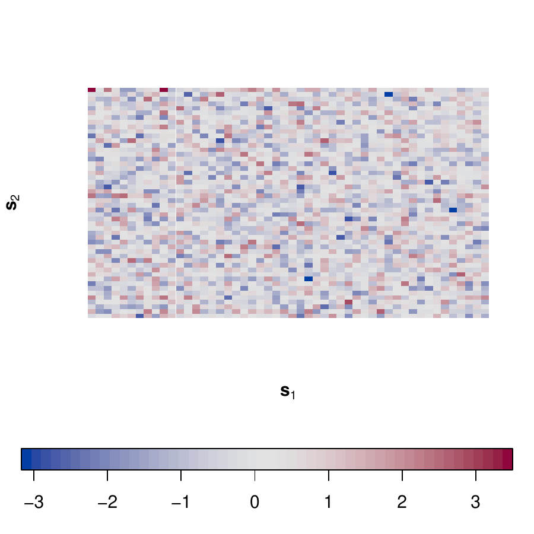

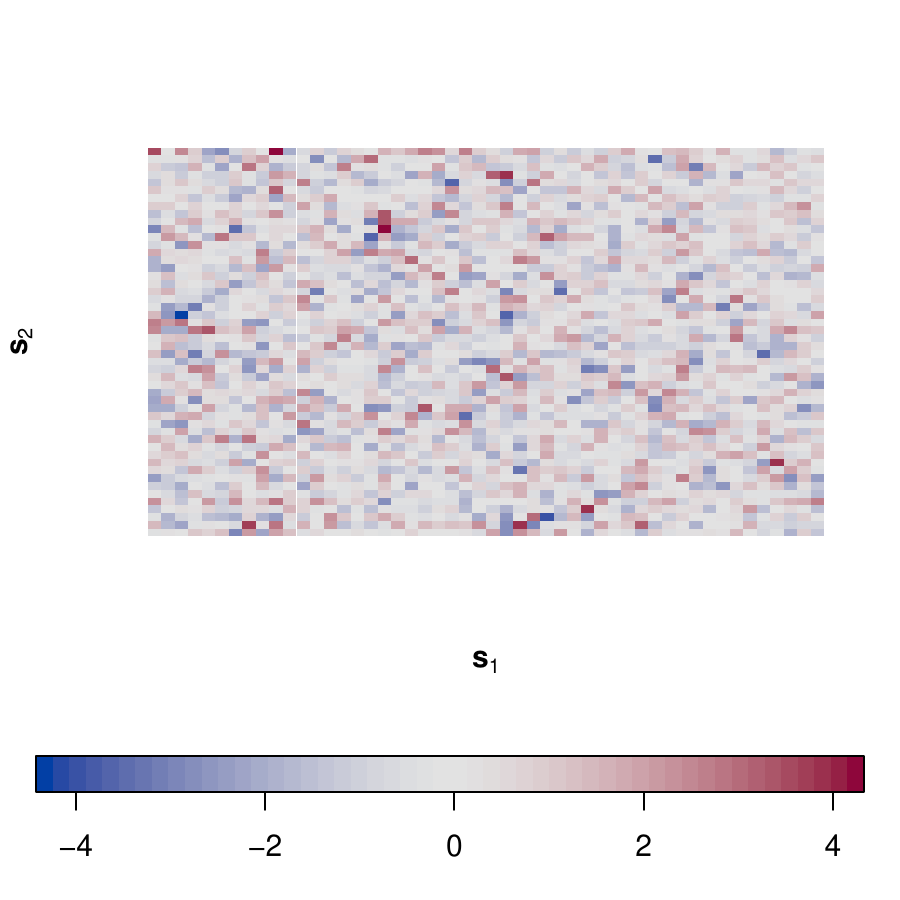

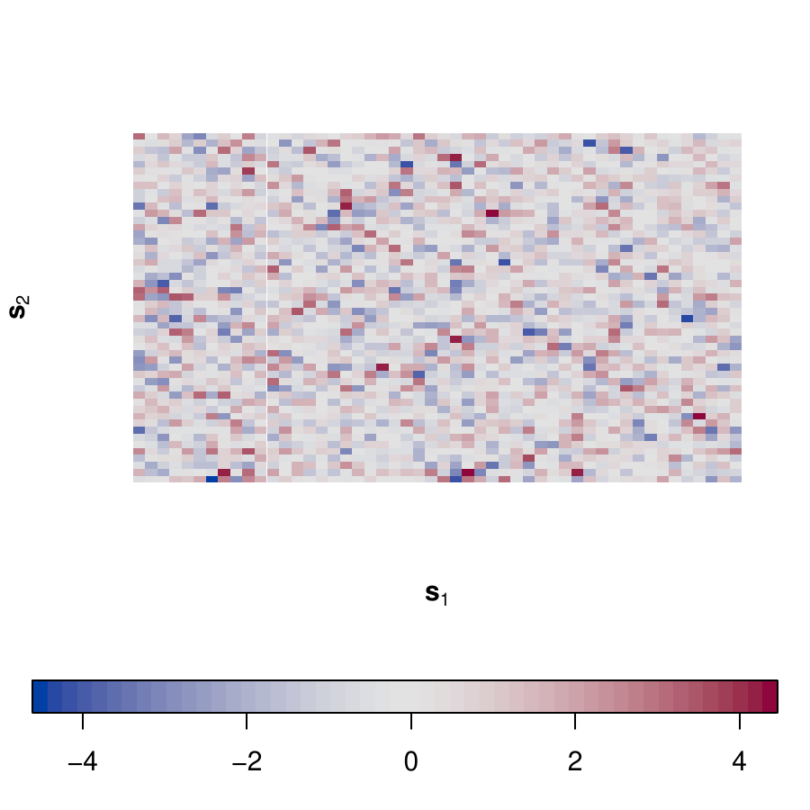

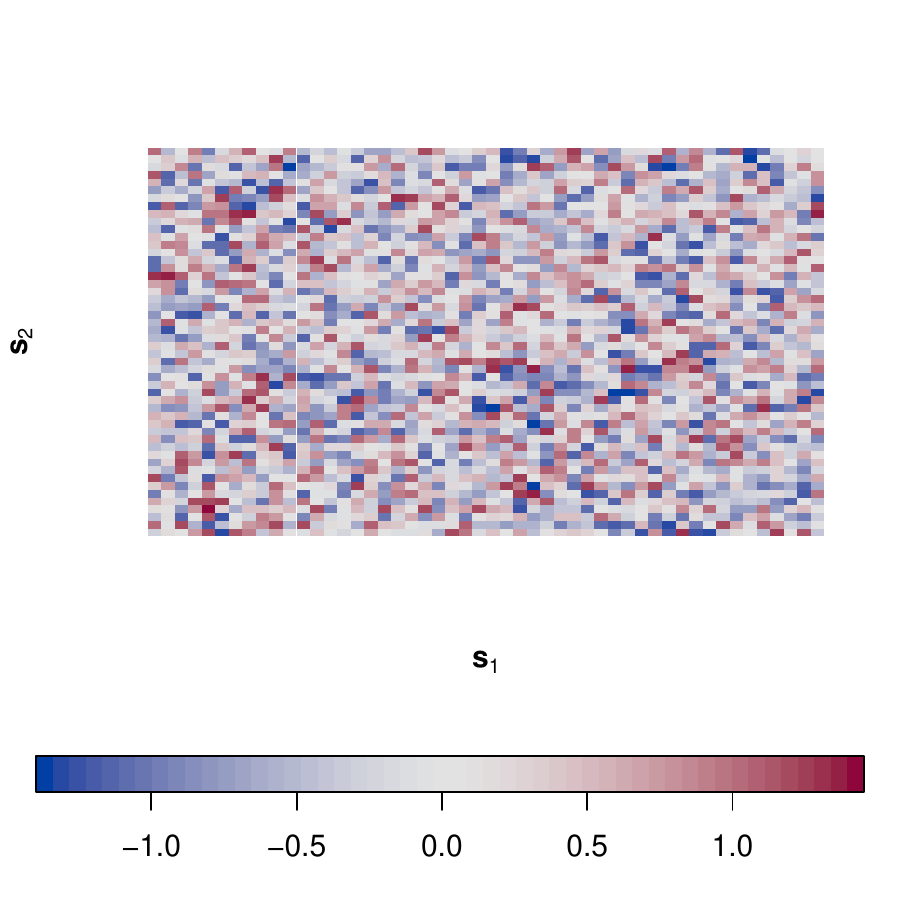

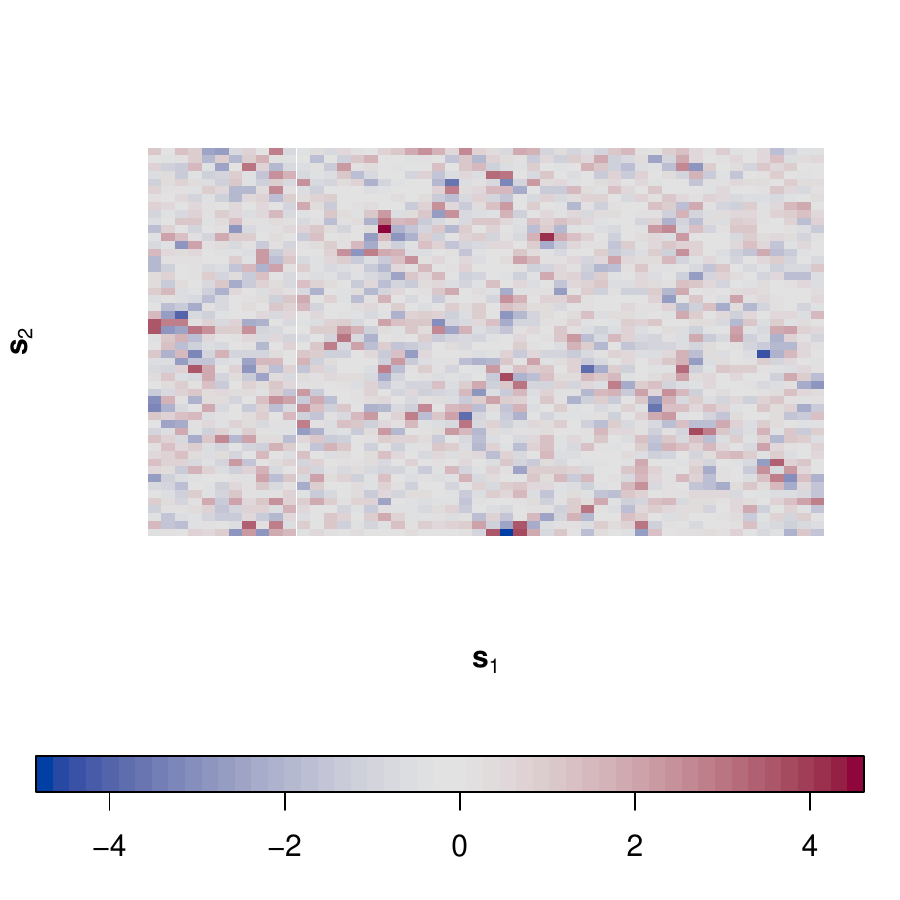

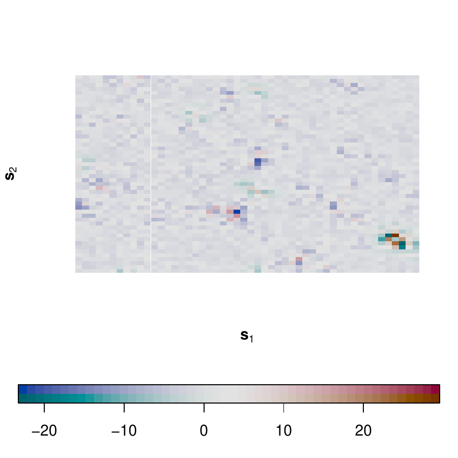

Above left: spatial white noise for comparison; center: oriented spARCH (`type = “gaussian”`); right: spatial E-ARCH (`type = “exp”`).  
Below left: spARCH with truncated normal errors (`type = “gaussian”`); center: spatial E-ARCH (`type = “exp”`), right: complex spARCH (`type = “complex”`).

Figure 2: Simulations on a two-dimensional lattice for triangular matrices (above) and non-triangular matrices (below). For all simulations, we set *ρ* = 0.7 and *α* = 1, and $W$ is chosen to be the Queen’s contiguity matrix.

As pointed out in Section 2, spatiotemporal ARCH models are directly covered if time is considered as one dimension of the $q$-dimensional space $D$. Thus, a two-dimensional spatiotemporal process $\{Y_{t}(\boldsymbol{s}) : t = 1, \ldots, T; \boldsymbol{s} \in D_{\boldsymbol{s}}\}$ with $D_{\boldsymbol{s}}$ being a $d \times d$ unit grid and $T = 20$ points of time could be simulated as follows.

```r
R> d      <- 4
R> T      <- 20
R> D_s    <- 1:(d^2)
R> D_t    <- 1:T
R> n      <- length(D_s) * length(D_t)
R> nblist <- cell2nb(d, d, type = "queen")
R> W_list <- nb2listw(nblist)
R> W_s    <- Matrix(listw2mat(W_list))
R> W      <- W_s
R> for(t in D_t[-1]){
R>   W    <- bdiag(W, W_s)
R> }
R> diag(W[-c(1:length(D_s)), -c((n - length(D_s)+1):n)]) <- 0.2
R> set.seed(1)
R> Y      <- sim.spARCH(n = n, rho = 0.8, alpha = 1, W = W, type = "log-spARCH")
```

The spatial weighting scheme has been chosen as block diagonal matrix like proposed above, i.e., constant matrices $\mathbf{W}_1 = \mathbf{W}_2 = \ldots = \mathbf{W}_T = \mathbf{W}_s$ along the diagonal define the instantaneous spatial interactions, while constant weights of $0.2$ below the diagonal define the extend of the temporal dependence. For instance, a central location would be weighted equally by all eight spatial neighbors with a weight of $0.125$ and by the observation of the same location at the previous time point by $0.2$. Thus, $\mathbf{W}$ describes the structure and the extend of the dependence in space and time. Eventually, $\rho$ has been chosen as $0.8$ and we simulated the process as logarithmic spatial ARCH process.

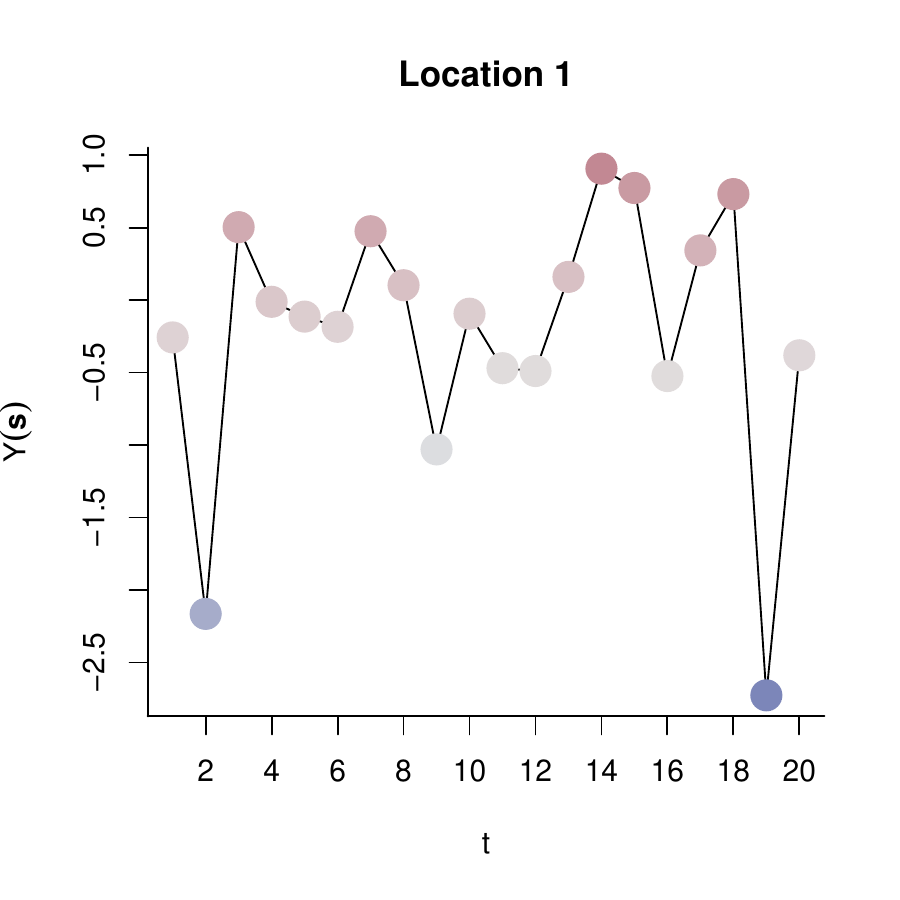

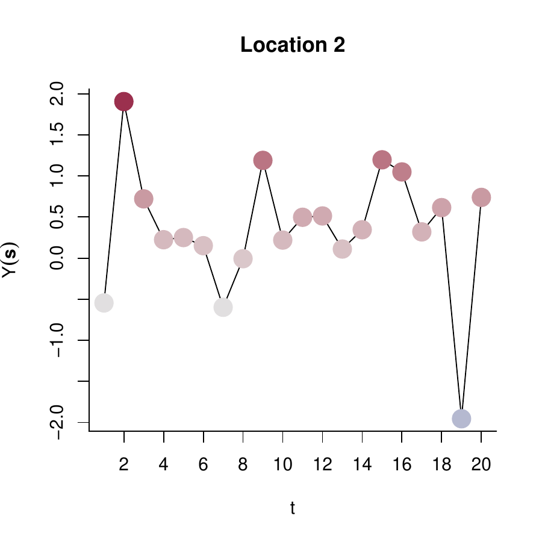

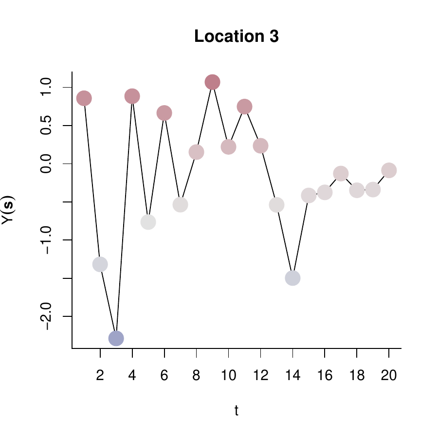

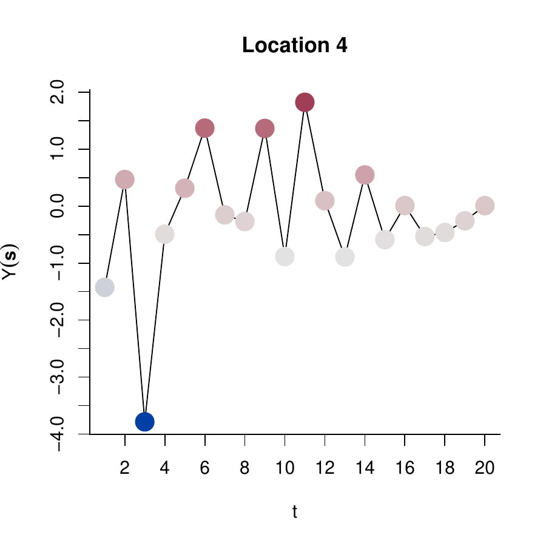

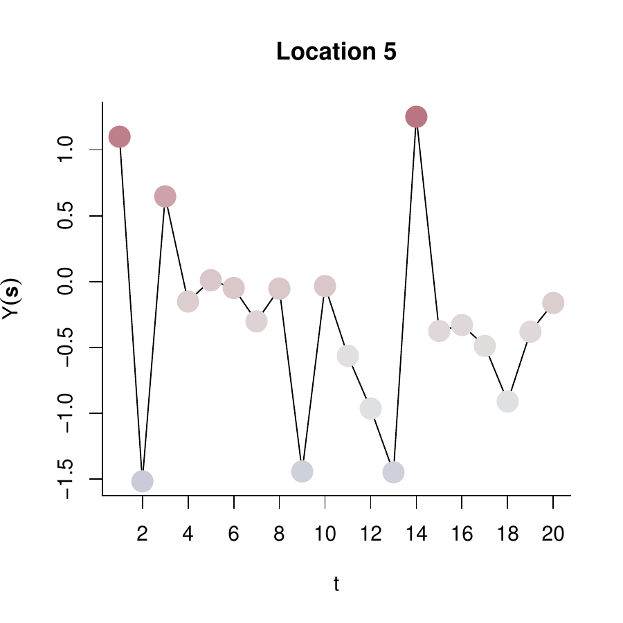

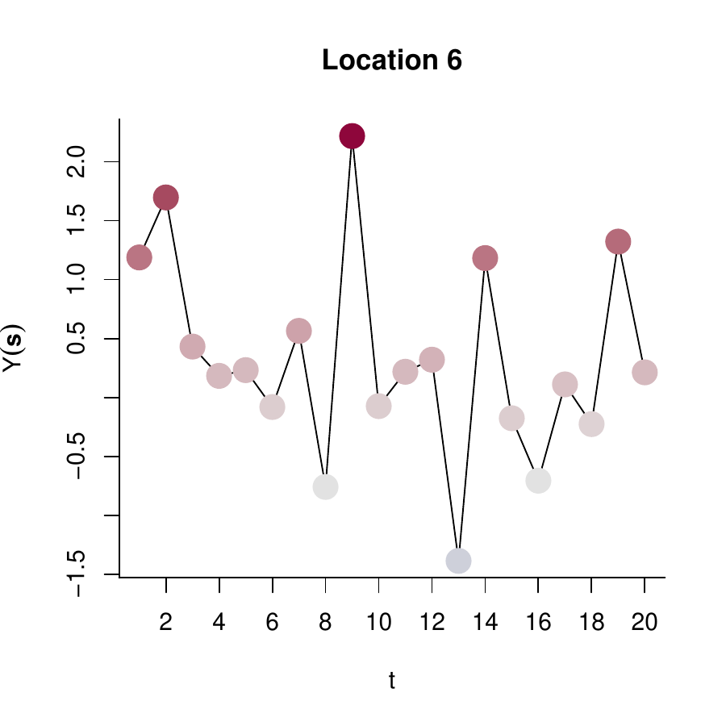

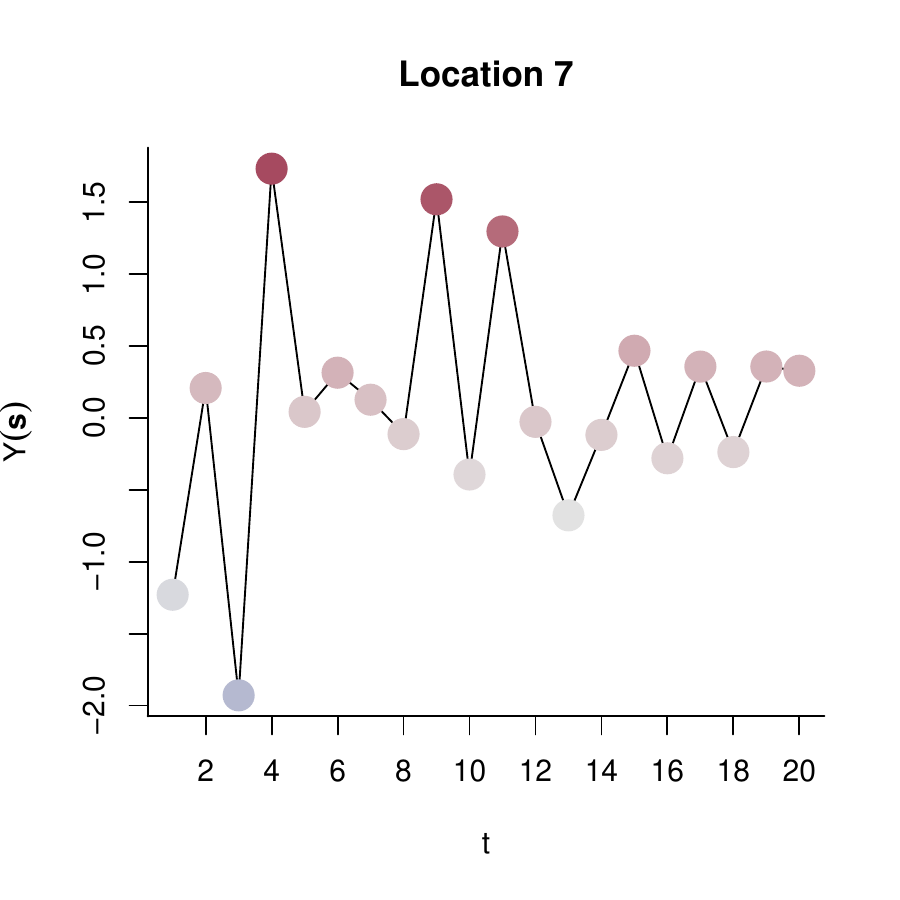

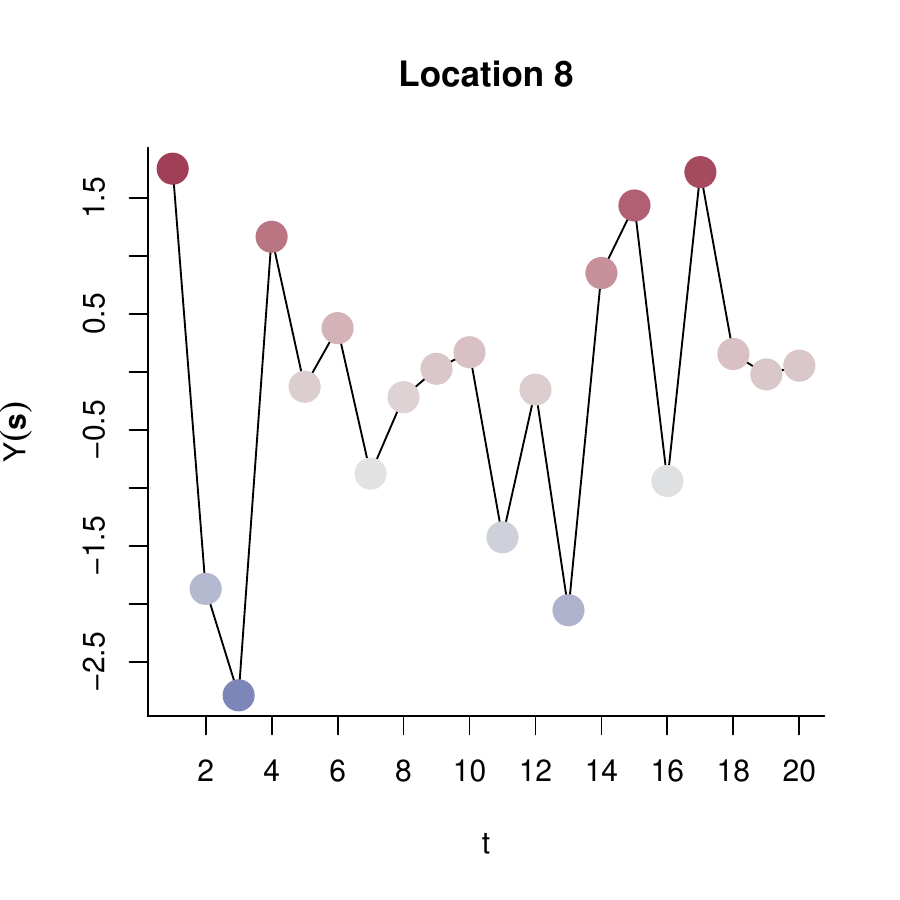

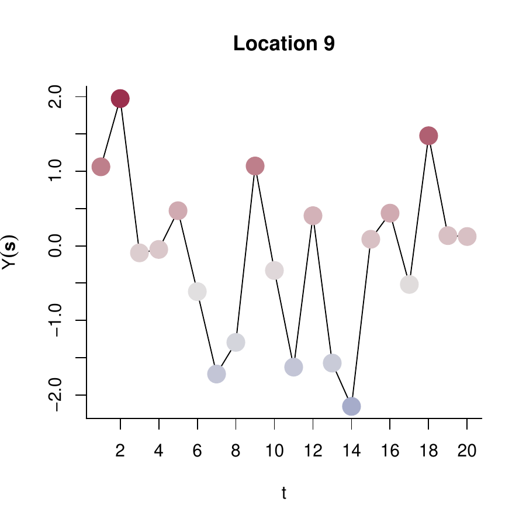

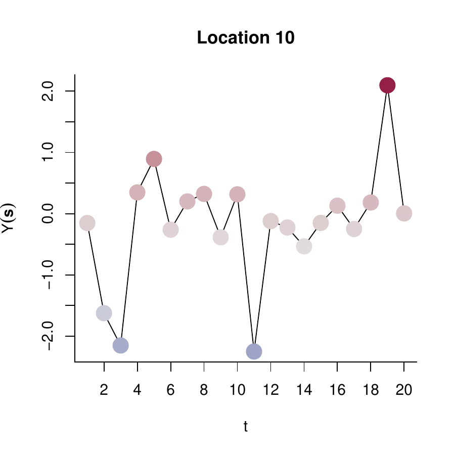

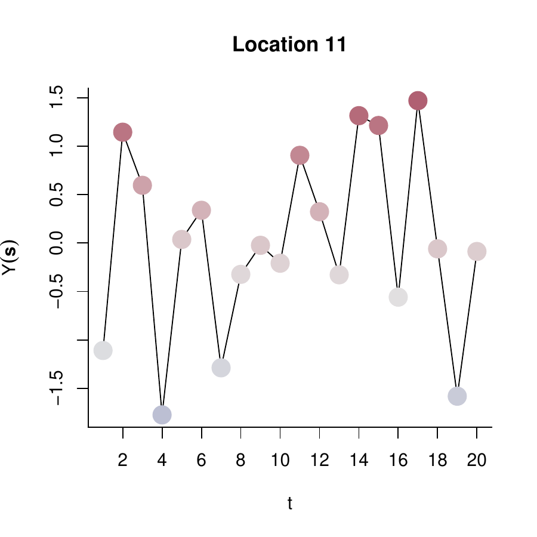

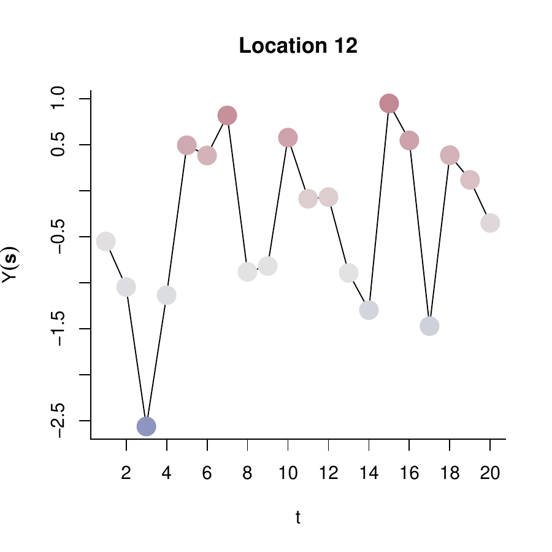

[4 more figures not shown]

Note that the true spatial orientation is preserved in this representation ($4 × 4$ grid), i.e., plots appearing close to each other are also located close to each other in space and they are, therefore, more related than more distant locations. An alternative representation as consecutive spatial random fields is shown in Figure .

Figure 3: Simulated spatiotemporal log-ARCH process depicted as individual time series. The process has been simulated on a $4 × 4$ spatial unit grid and for 20 points in time. The spatial ARCH parameter *ρ* equals 0.9 and *α* = 1.

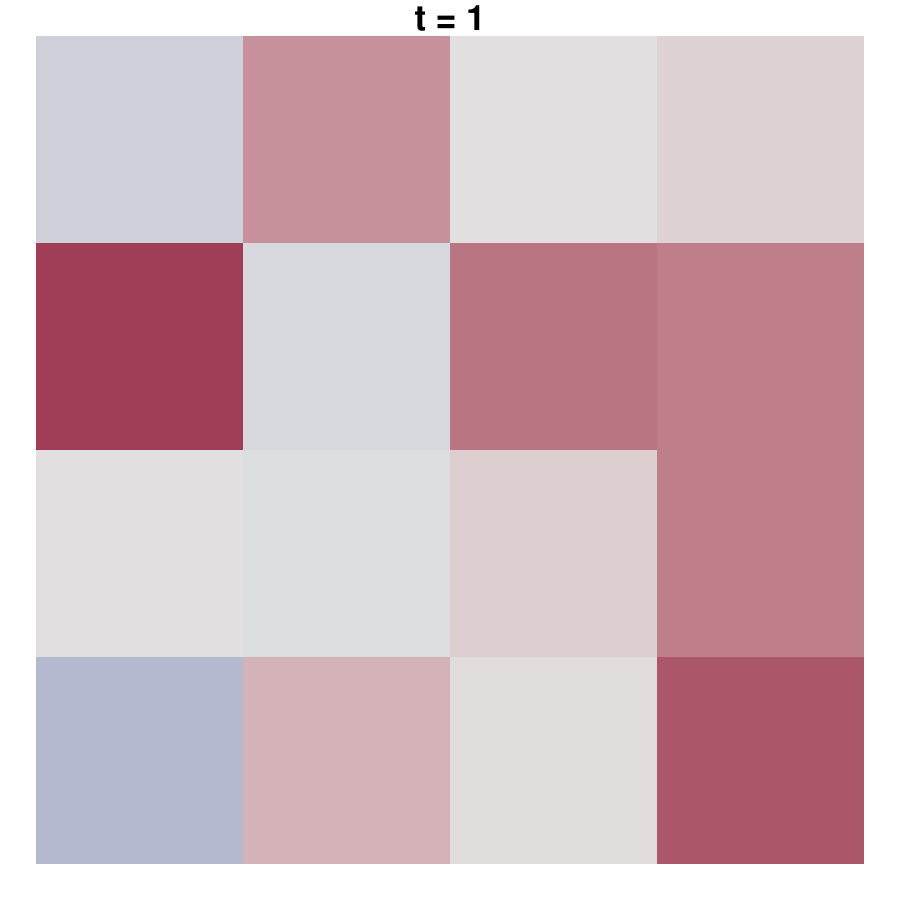

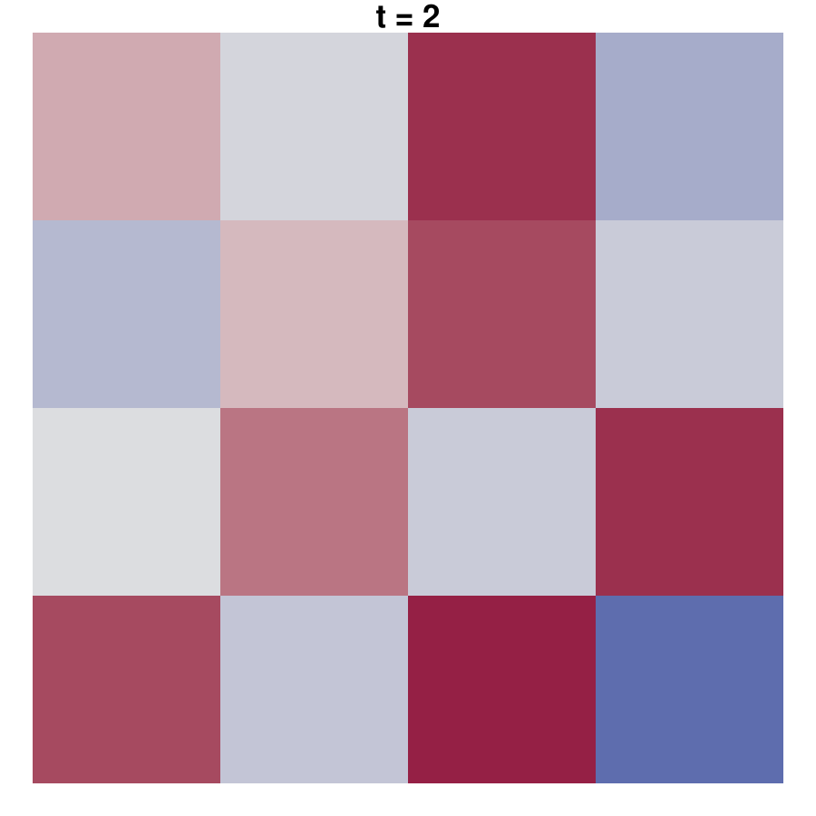

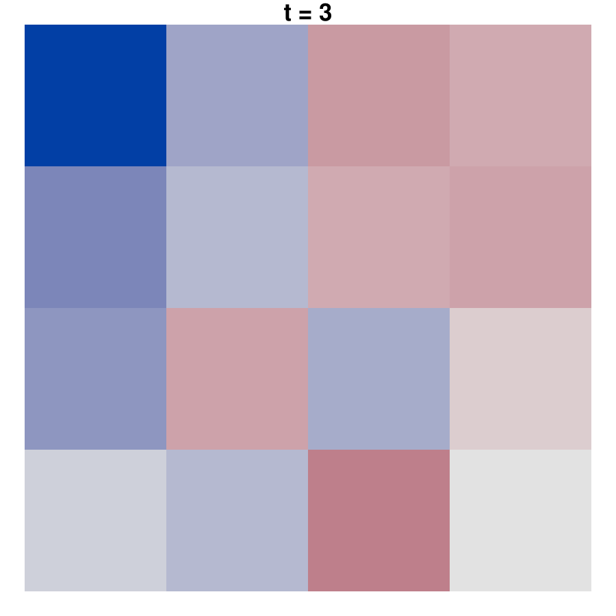

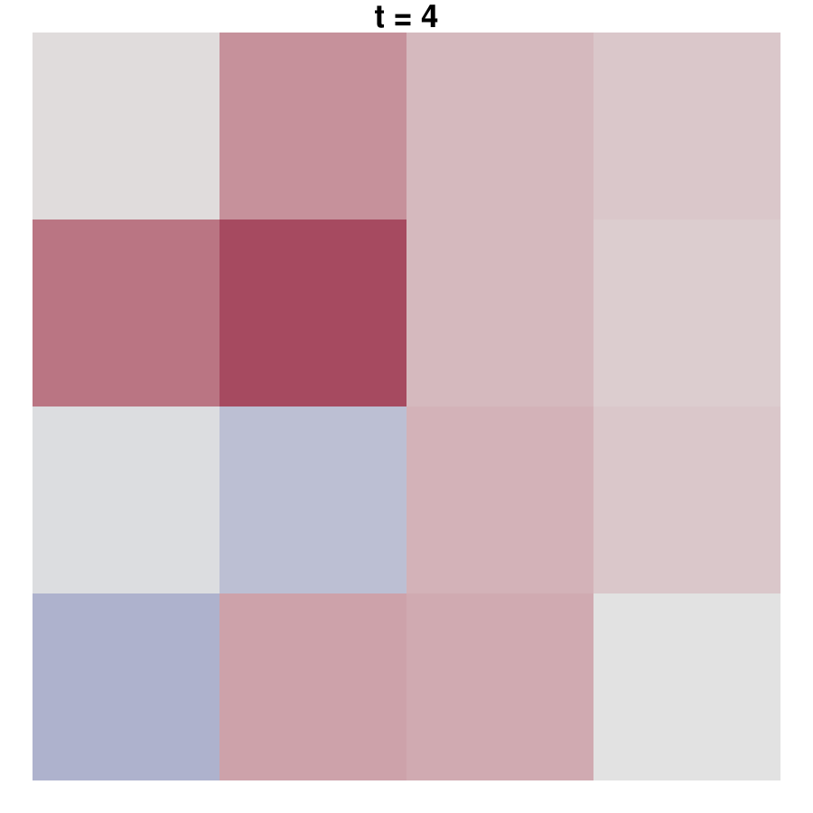

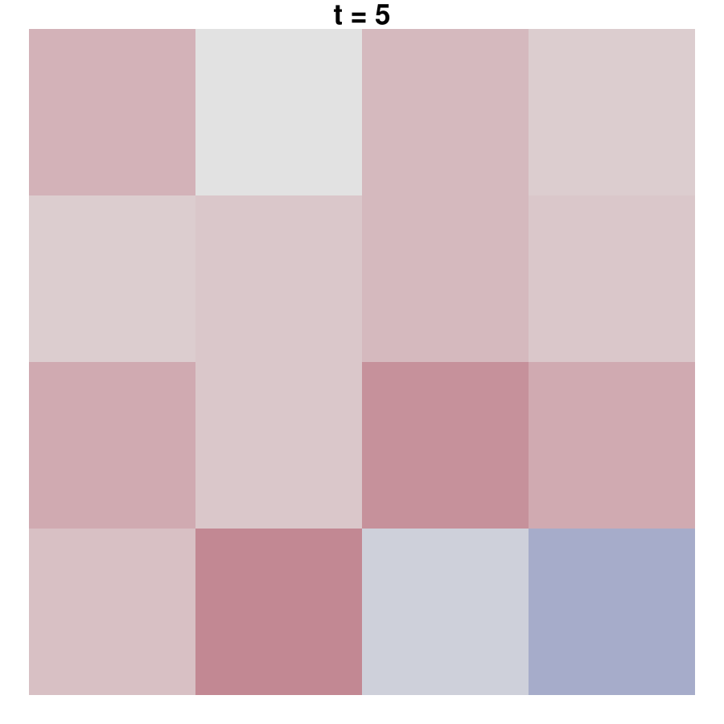

…

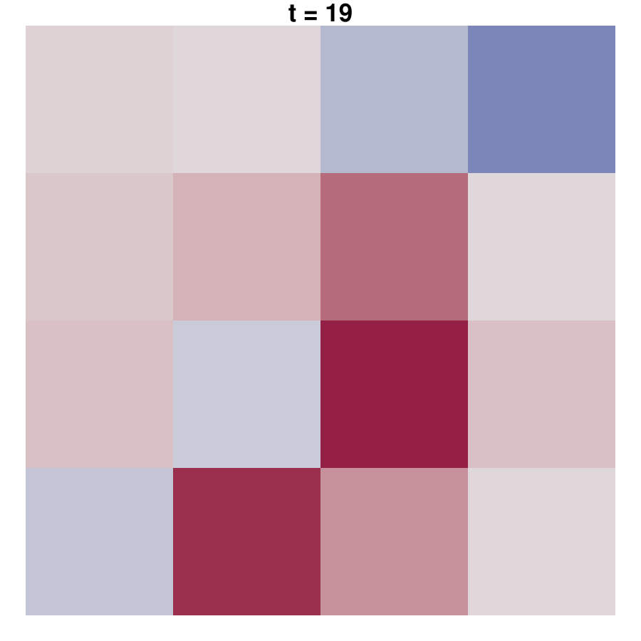

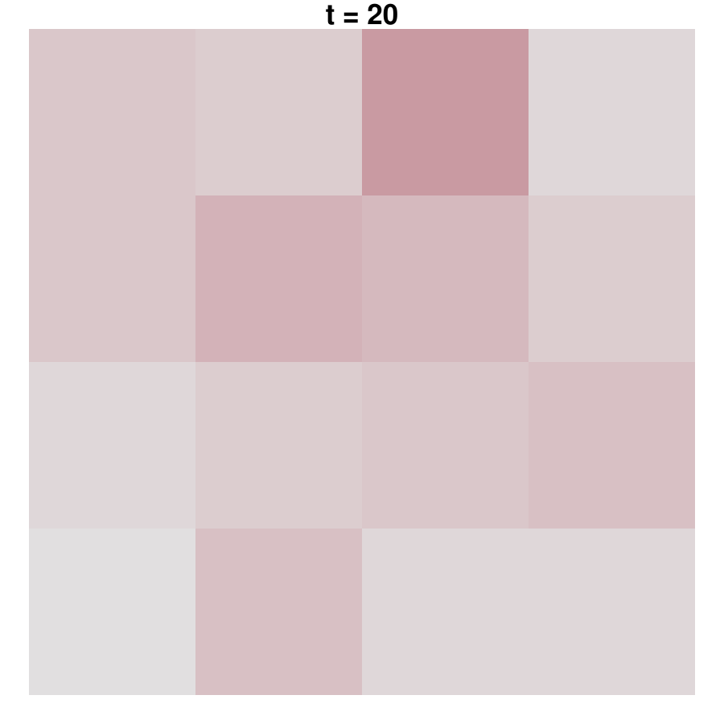

The first five and the last two time points are plotted as spatial random fields, i.e., the simulations are shown in their natural temporal ordering. An alternative representation as time series in their true spatial ordering is shown in Figure .

Figure 4: Simulated spatiotemporal log-ARCH process depicted as consecutive spatial random fields. The process has been simulated on a $4 × 4$ spatial unit grid and for 20 points in time. The spatial ARCH parameter *ρ* equals 0.9 and *α* = 1.

For sake of completeness, we briefly demonstrate the simulation of spatial GARCH-type models using the `sim.spGARCH()` function. Like for `sim.spARCH()`, the type of the spatial GARCH model can be chosen by the argument `type`. More precisely, there are the following options

- `type = "spGARCH"` for simulation of spatial GARCH models according to the definition in (11),
- `type = "e-spGARCH"` for simulation of exponential spatial GARCH models according to the definition in (12) with $g$,
- `type = "log-spGARCH"` for simulation of logarithmic spatial GARCH models according to the definition in (12) with $g_b$, and
- `type = "complex-spGARCH"` for simulation of a complex-valued spatial GARCH model.

To simulate a spatial GARCH process, two spatial weights matrices need to be specified via the arguments `W1` and `W2`. Moreover, two parameters $\rho$ and $\lambda$ are passed to the simulation function by the arguments `rho` and `lambda`. For instance, a spatial GARCH model can be simulated on a $d \times d$ spatial unit grid as follows

```r
R> require("spdep")
R> rho    <- 0.5
R> lambda <- 0.3
R> alpha  <- 1
R> d      <- 20
R> nblist <- cell2nb(d, d, type = "rook") # Rook's contiguity matrix
R> W_1    <- nb2mat(nblist)
R> W_2    <- W_1
R> Y      <- sim.spGARCH(rho = rho, lambda = lambda, alpha = alpha,
+                        W1 = W_1, W2 = W_2, type = "spGARCH")
```

Similarly, spatial log-GARCH processes and exponential spatial GARCH processes can be simulated by changing the argument `type`. In this case, the parameters $b$ must be provided for the log-GARCH or $\Theta$ and $\zeta$ for the e-spGARCH, respectively. These parameters can easily passed to `sim.spGARCH()` by the arguments `b`, `theta`, and `zeta`.

### 5.2 Maximum-likelihood estimation

Other important functions of the package are the `qml.spARCH()` and `qml.SARspARCH()` functions, which implement a quasi-maximum-likelihood estimation algorithm (QML). As for the `sim.spARCH()` function, many spARCH models are covered in the `qml.spARCH()` and `qml.SARspARCH()` function. Thus, the user needs to specify which particular spARCH model is to be fitted via the argument `type`. Moreover, the model for the mean equation is a user-specified `formula`, making the use of the estimation functions similar to the use of the common `lm()` or `glm()` functions.

In general, the estimators exhibited good performances for a variety of error distributions in simulation studies, although the likelihood function was derived under the normality assumption. This is not surprising, as the maximum-likelihood estimators have good properties under mild assumptions for the error processes of a variety of similar spatial econometrics models (cf. Lee (2004; Lee and Yu 2010a,b; 2012)). Thus, we refer to the approach as the QML approach, and the name of the estimation functions start with `qml` instead of `ml`. In the following paragraphs, we start the simulation of one specific sample, which is then used further to illustrate the log-likelihood functions as well as to demonstrate parameter estimation.

Compared to the log-spARCH processes, the likelihood functions of spARCH models are rather flat around the global maximum. This behavior is illustrated for simulated processes in Figure 5. The observations for the log-spARCH process have been simulated as follows.

```r
R> nblist          <- cell2nb(20, 20, type = "queen")
R> W               <- nb2mat(nblist)
R> y               <- sim.spARCH(n = 20^2, rho = 0.5, alpha = 1, W = W,
+                              type = "log-spARCH", control = list(seed = 5515))
```

To simulate an oriented process, the entries of $\mathbf{W}$ above the diagonal must be set to zero and the argument `type` must be changed to `"spARCH"`, i.e.,

```r
R> W[upper.tri(W)] <- 0
R> y2              <- sim.spARCH(n = 20^2, rho = 0.5, alpha = 1, W = W,
+                                 type = "spARCH",
+                                 control = list(seed = 5515))
```

**spARCH process**

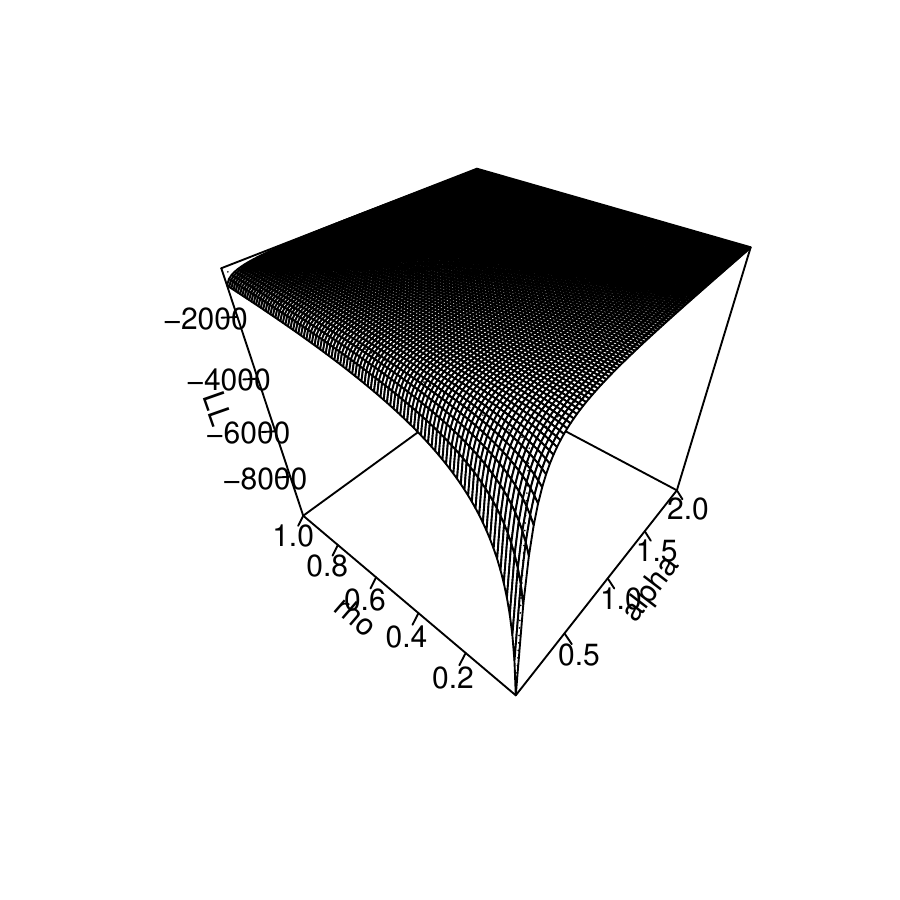

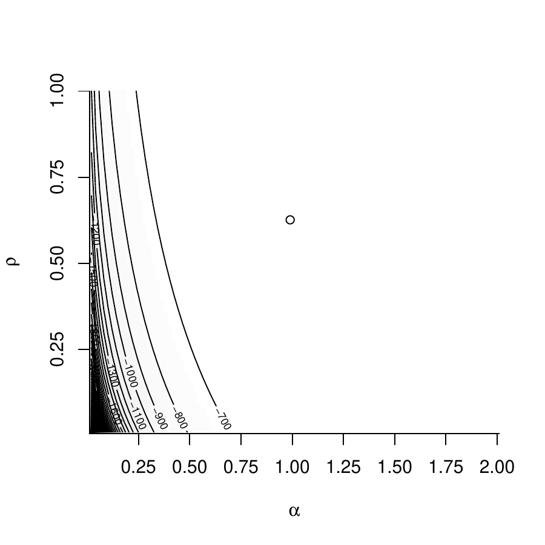

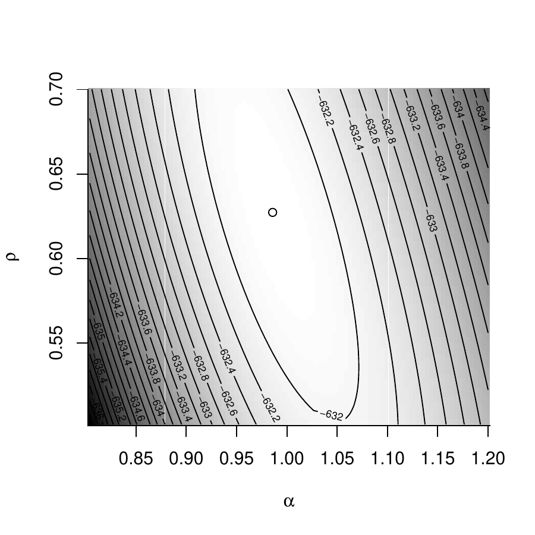

**log-spARCH process**

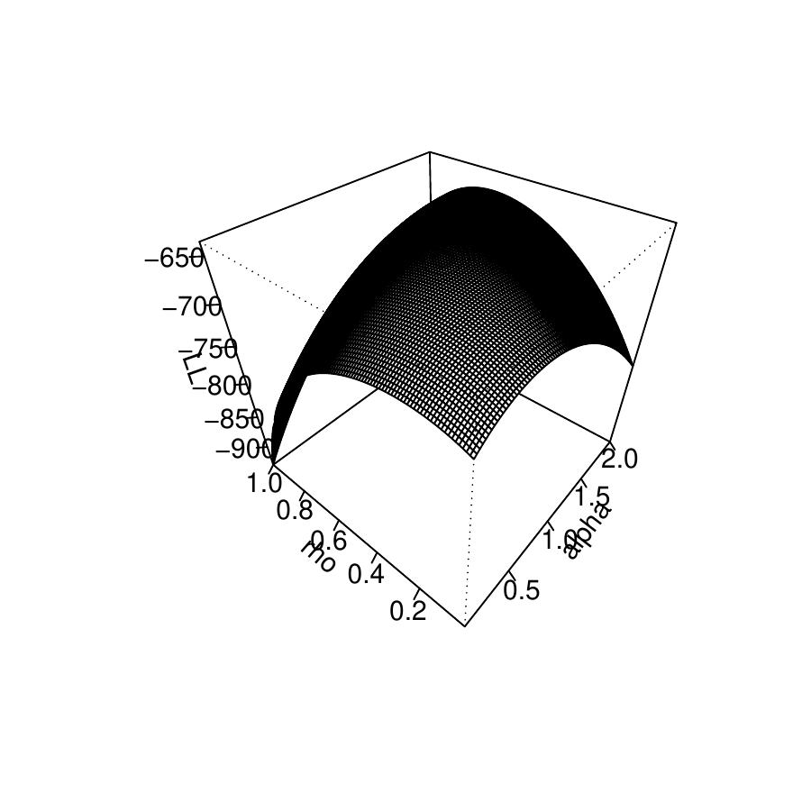

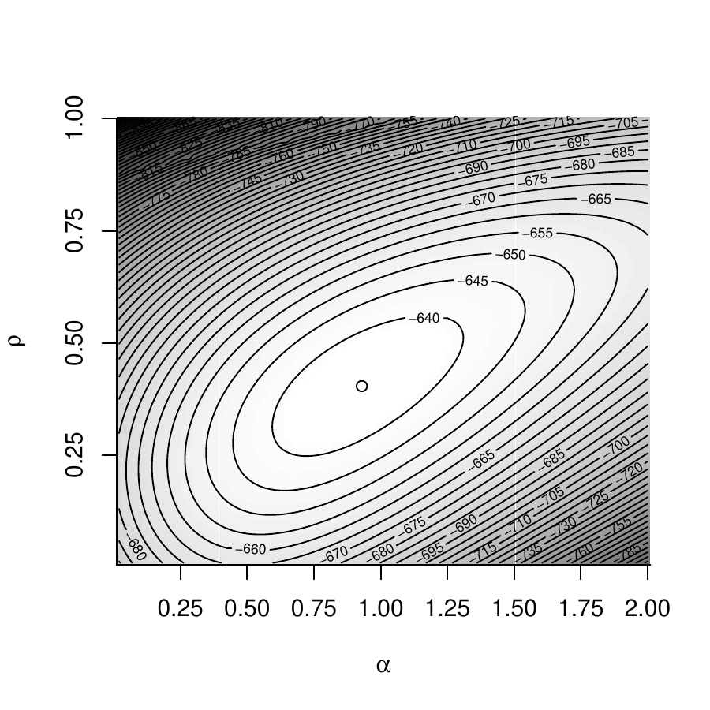

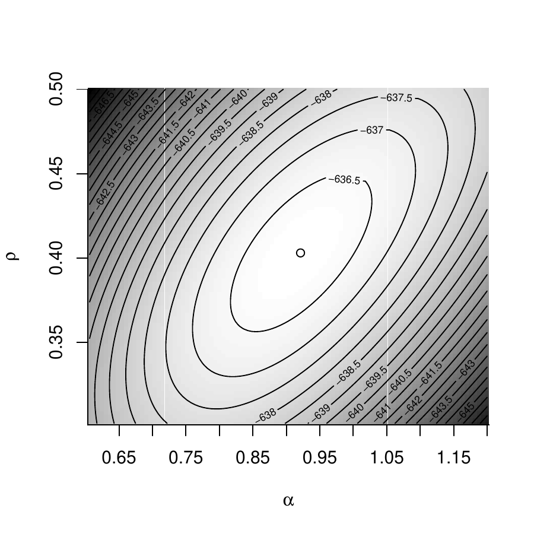

Figure 5: Logarithmic likelihood function.

To estimate the parameters of an intercept-free log-spARCH model without any regressors, the formula passed to the function `qml.spARCH()` should be specified as `y 0`. In addition, a `data.frame` can be passed via the `data` argument to the `qml` functions. Although the likelihood function of a spARCH process is flat, good estimates can be obtained through iterative maximization. (Otto et al. 2018) analyze the performance of the estimators in detail. The algorithm implemented in the packages is based on the [*Rsolnp*](https://CRAN.R-project.org/package=Rsolnp) package, allowing for both equality and inequality parameter constraints (cf. Ghalanos and Theussl (2012)).